# DSCI 100 - Introduction to Data Science

## Lecture 1 - Getting started with Jupyter & R

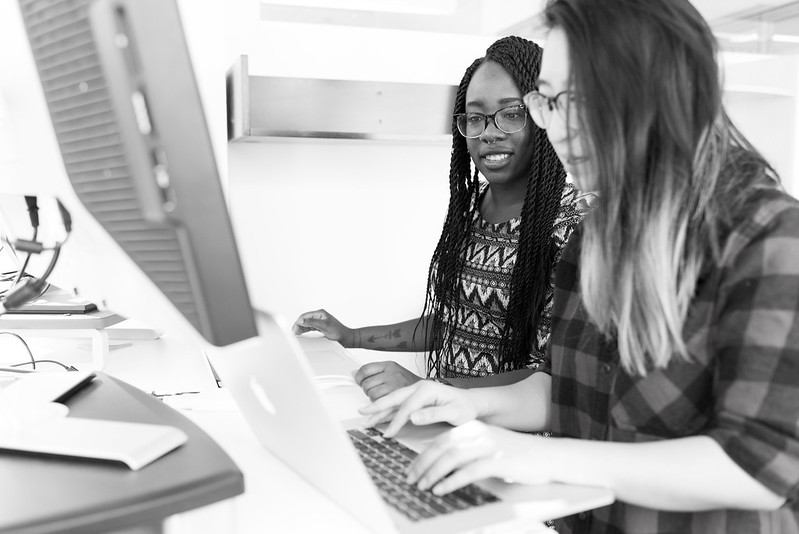

*Photos/Images by #WOCinTech/#WOCinTech Chat ([CC-BY](https://creativecommons.org/licenses/by/2.0/))*

## Teaching Team Introductions

### Instructors

- Section 002 (R) Tue/Thu 10:30 - 13:30 Daniel Chen
- Section 003 (R) Tue/Thu 13:30 - 16:30 Vivian Meng

### Course coordinator

- Julia Peng (courses@stat.ubc.ca)

**If you have administrative questions (e.g. are sick and going to miss a quiz), please read the FAQ and contact the course coordinator**

## Your turn!

- We encourage you to work collaboratively throughout DSCI 100
- Let's start by getting to know the person next to you
  - Introduce yourself
  - Which program are you from?
  - Why are you interested in Data Science?
  - Anything else you want to mention!

## Some housekeeping (Online)

- Please stay muted except when speaking to reduce the background noise for other students
- Have Questions?:
  - ask it in the chat and a TA will respond
  - raise your hand (click "Participants", then click "Raise Hand.") and I'll call you to unmute and speak
- Please note the session will be recorded and posted on Canvas
- Please ensure your audio and video works once you join the room

## Sick Policy

Our primary goal is keeping everyone as safe as possible.

For COVID: See [UBC's COVID-19 Campus Rules](https://srs.ubc.ca/health-safety/safety-programs/communicable-disease-prevention-framework/covid-19/) for the latest updates.

- **Masks:** Masks are optional when you are in class. Please respect the individual preferences of your classmates/instructors.
- **Vaccines:** Getting vaccinated is good. Please get vaccinated if you are able to, for your safety and others'.
- **If you feel unwell, it doesn't matter what it is: STAY. HOME.**
  - you can do your assignments remotely
  - we can make alternate arrangements for quizzes
  - I will drop the lowest worksheet + tutorial score at the end of class

[figure not shown]

## Course Guidelines

Visit and abide by the course Code of Conduct on Canvas.

Basically: **be good to each other.**

- Help other students if they're struggling
- Respect others while they speak; don't interrupt
- Come to class prepared
- Value diversity, respect everyone's ideas
- Be aware of how much you are contributing to class
  - If you tend to speak often, allow others to speak
  - If you tend to stay quiet, challenge yourself to share ideas so others can learn from you
- Listen actively, and be mindful of each other's differences
- Avoid demeaning, devaluing, or "putting down" people
- Trust that people are doing the best they can. Be as patient as possible with the learning processes of others
- Respect your teaching team, and expect professionalism and respect in return

e.g.: Posting a "let me google that for you" link on Piazza in response to another student's question. Please don't do this. Remember: students in this class come from a wide variety of backgrounds - **be good to each other!**

[figure not shown]

## What *is* data science exactly?

**Data science** is the use of *reproducible* and *auditable* processes to obtain value (i.e., insight) from data.

## High-level goals of this course:

1. Learn how to use reproducible tools (Jupyter + R) to do data analysis
2. Learn how to identify and solve 4 common problems in data science

## Problems we will focus on:

1. Predict a class/category for a new observation/measurement (*e.g.,* cancerous or benign tumour)
2. Predicting a value for a new observation/measurement (e.g., 10 km race time for 20 year old females with a BMI of 25)
3. Finding previously unknown/unlabelled subgroups in your data (e.g., products commonly bought together on Amazon)
4. Estimating an average or a proportion from a representative sample (group of people or units) and using that estimate to generalize to the broader population (e.g., the proportion of undergraduate students that own an iphone)

## Brief Canvas walkthrough:

https://canvas.ubc.ca/courses/140683

Read the Syllabus and Frequently Asked Questions pages carefully!

## TL;DR

Yes, you satisfy the math requirement. There is no math requirement. Ignore SIS's scary warnings.

[figure not shown]

But please do read the syllabus in more detail later!

## Class activity:

### Practice using LaTeX and code formatting in Piazza!

Your task: Create a Piazza post in the `other` folder to say hello and introduce yourself to everyone. In that post include the following code formatted as code, and the following LaTeX formatted as Math:

Code to include:

```
whyamihere = "to learn data science!"
```

LaTeX to include:

```
datascience = (statistics + computerscience)^2
```

### Lecture/Tutorial Structure

- We will post a reading before each class.
  - e.g. the first chapter is `reading_01`
- **The readings often provide example answers for the questions in worksheets and tutorials!**
- We will kick off each lecture with a little intro
  - the slides should be up before each lecture, e.g. `slides_01`
- You will have one *graded* assignment per lecture / tutorial
  - Lecture worksheets start in the first class each week, due **Saturday 11:59pm**
  - Tutorial worksheets start in the second class each week, due **Saturday 11:59pm**
- There will usually be an *ungraded* activity/demo in lectures and tutorials
- No "submit button" - our server takes a snapshot at the due date/time
- We won't give extensions for weekly assignments. We will drop the lowest grade for each worksheet and tutorial at the end of the semester.

### Assignments

- Lectures during the first class each week.
  - Lecture worksheets (e.g. `worksheet_intro`) are due **Saturdays at 11:59pm**
- Tutorials during the second class each week.
  - Tutorial worksheets (e.g. `tutorial_intro`) are due **Saturdays at 11:59pm**
- No "submit button" - our server takes a snapshot at the due date/time
- Please make sure you **manually save your work! Do not rely on automatic checkpoints!**
- The server should basically be on 24 / 7. I will give notice before we shut it down (barring any emergencies).
- See the course syllabus for two common mistakes to avoid for autograded assignments
- Each worksheet is not worth a lot of points -- they are designed to help you learn, not evaluate you.
  - **Please do collaborate, but do not copy!**
  - We won't give extensions for weekly assignments. We will drop the lowest grade for each worksheet and tutorial at the end of the semester.

### Main Evaluations

- One midterm covering ~6 weeks of material (summer ~3 weeks)
  - Same time & location of week 7's tutorial (summer week 4). Invigilated in-person.
- One final covering all the material in the course
  - To be scheduled by Classroom Services. Invigilated in-person.
- An **individual** project
  - You can collaborate with other people in class, but the work should be yours

### First week learning goals:

- Edit and execute code and markdown in Jupyter notebooks
- Do the basics of data manipulation and visualization in R
- Use the help and documentation tools in R

## We've got a lot to do - let's get started!

[figure not shown]

I'll begin with a quick Jupyter notebook demo using your first assignment, Worksheet 1.

- What is a notebook?
- Cells with either code or text
- Run with play button
- Saving notebook
- Restart kernel and run all before submitting
- Remove `raise NotImplementedError` when entering your code
- Shut down the server when you are done
- If you run into a technical issue you can't solve, first try to restart the kernel
  - Click the menu in the top left: `Kernel -> Restart Kernel and Run All`
- If the problem persists, restart your Jupyter server instance.
  - Save the notebook (avoid losing work). Download it to be extra safe.
  - Click `File -> Hub Control Panel`
  - Click "Stop my server"
  - Click the Log Out button in the top right corner
  - Close all JupyterLab tabs
  - Refresh Canvas page, click worksheet link again

## Now it's your turn!

- Navigate to Canvas, open `worksheet_intro`
- Use Firefox or Chrome, not Safari

**Note:** You will all be using a shiny brand new server that we host in the Statistics department. This course is "bleeding edge" -- we do a lot of things that no other course does behind the scenes. So:

- Be patient if something doesn't work. We will do our best to debug things as quickly as possible
- We will always be fair about deadlines/grading/etc when our hardware acts up.

And, **Warning:** Do not ever delete or change the name of any file in your Jupyter home folder!

- We rely on very specific filenames to retrieve your submitted work automatically
- If you rename or move things, our system *will not find your assignment submission*
- If you accidentally change the filename or move/delete a file, tell me or a TA as soon as possible so we can help you

## Academic Skills Certificates (first-term UBC science student)

[figure not shown]

https://science.ubc.ca/students/academic-skills-certificate

# Getting started with Zoom

1. Move your cursor to the top of the screen and click on View Options

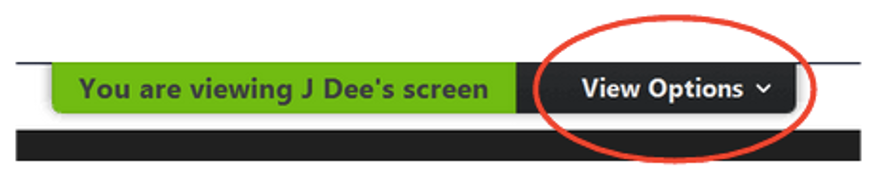

2. Click on Annotate

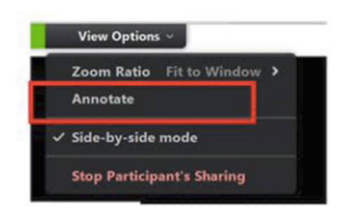

3. Annotation tools should appear.

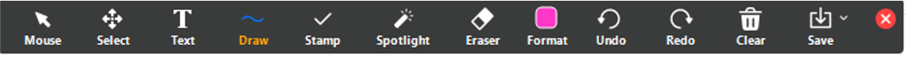

# How do you currently feel about this upcoming semester?

#### Put a stamp icon on the line to indicate how you're feeling

[figure not shown]

# Active listening online

- Active listening behaviours are important to having a good conversation on Zoom.
- Without active listening the speaker is left wondering if anyone is actually on the call (has everyone run off to get a coffee??) or whether their microphone has stopped working.

## Group work

- Go to your breakout room groups and work together on the worksheet!
- Discuss with your neighbours, the TAs & Instructors, and consult [the textbook reading](https://datasciencebook.ca/) to help you get unstuck when needed!
- You can "share screen" with each other to code/ask each other questions and "ask for help" to ask me or the TAs questions while in the breakout rooms!

### Group Roles

**How long was your commute for class?**

Assign the following roles based on who had the longest commute:

1. **Facilitator** (longest commute): Keeps group on task and verifies that all contribute.
2. **Recorder/Screen sharer**: Takes notes on important thoughts expressed in the group. Writes down any questions the group has for the TA or instructor. If TA/instructor joins your group, recorder asks the TA/instructor your question(s). Shares screen with group.
3. **Time Keeper/Reporter**: Keeps track of time and reminds group how much time is left. Shares summary of group with large group. Speaks for the group, not just personal view.
4. **Editor** (shortest commute): Checks for accuracy and clarity of thinking during discussions. Checks written work and tracks points.

## Video and audio

If you have access to both video and audio on Zoom (either by technical availability, or choosing to turn on your camera), below are ways you can perform active listening on Zoom to cue to someone you are speaking with that they can hear you.

- In large groups, where the gallery view may take > 1 page on Zoom, or when the speaker is screen sharing, nodding of your head and the thumbs up 👍 and 👏 reactions on Zoom are likely to be missed by the speaker.
  - selecting the thumbs up 👍 or clapping 👏 icon from the **participant panel** is the preferred way of demonstrating that you are following along. *Be sure to clear them when you are done expressing your active listening because these emoji's these remain present until you (or the meeting host) clears them.*
- In small groups,
  - body language that is viewable via your camera is one way to signal to others that you are listening (similar to a face-to-face conversation) e.g. looking at the camera, nodding when you agree
  - using the thumbs up 👍 or clapping 👏 reaction on Zoom is another way to signal that you are listening. You can use this in place of nodding if you prefer, or to provide emphasis on top of nodding.

## Audio only

If you only have access to audio on Zoom (either by technical availability, or by choosing to not turn on your camera), below are ways you can perform active listening on Zoom to cue to someone you are speaking with that they can hear you.

- In large groups,
  - selecting the thumbs up 👍 or clapping 👏 icon from the participant panel is the preferred way of demonstrating that you are following along. *Be sure to clear them when you are done expressing your active listening because these emoji's these remain present until you (or the meeting host) clears them.*
- In small groups,
  - unmute yourself and treat the call like a phone call, inserting verbal nods (e.g., “Uh-huh”, "I see", "Please go on") where appropriate.
  - using the thumbs up 👍 or clapping 👏 reaction on Zoom is one way to signal that you are listening. You can use this in place of nodding if you prefer, or to provide emphasis on top of nodding.

## Activity 1 (video & audio): Large group

Cameras on if you can. As I tell this story, practice using the **participants panel** thumbs up 👍 or clapping 👏 icons to listen actively. I will be paying attention to that panel.

## Activity 1 (video & audio): Small groups

Cameras on if you can. In your small breakout rooms, when you enter the room, please go into gallery mode.

Each of you can take turns speaking:

- Speaker: Introduce yourself. Tell your story of why you decided to enrol in DSCI100 (~ 1 minute each).
- Listeners: practice active listening using either body language that is viewable in the camera, or the thumbs up 👍 and 👏 reactions on Zoom.

## Activity 2 (audio only): Large group

**Cameras off now!** In this large meeting, I am going to tell a little story about why I use version control and ask you a few questions as I do so. As I tell this talk, practice using the participants panel thumbs up 👍 or clapping 👏 icons to listen actively and/or answer questions. I will be paying attention to that panel.

## Activity 2 (audio only): Small groups

**Cameras off now!** In your breakout rooms, each of can take turns speaking:

- Speaker: tell your story of what you are most excited to learn in DSCI100 (~ 1 minute each).
- Listeners: The others in the room should practice active listening using either by unmuting and providing verbal nods, or the thumbs up 👍 and 👏 reactions on Zoom. We encourage you to try both in this activity!